# Predator Median Prey Plots

Evan Doughty

7/27/2021

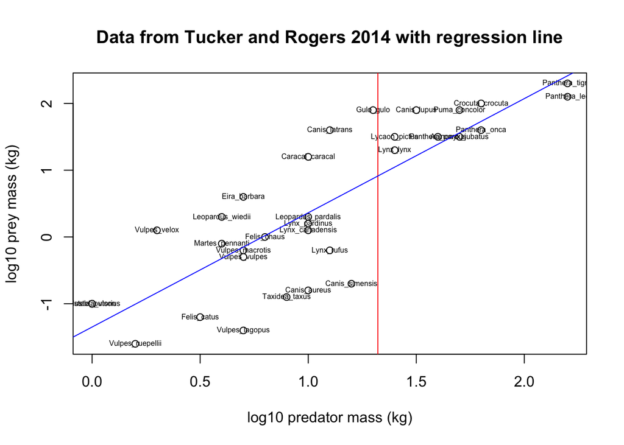

##Median Body mass of Prey of Predator Guild

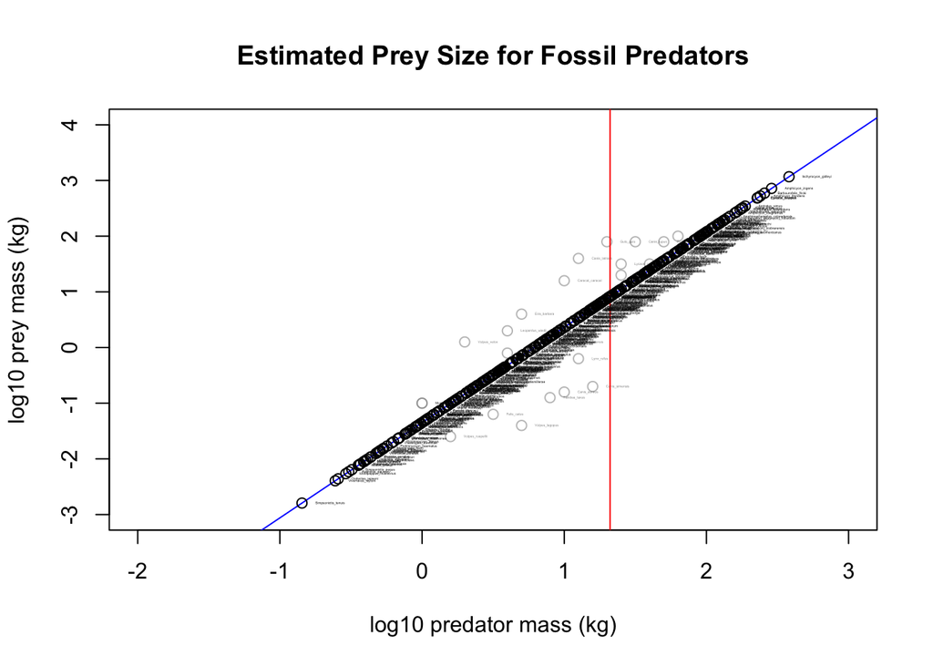

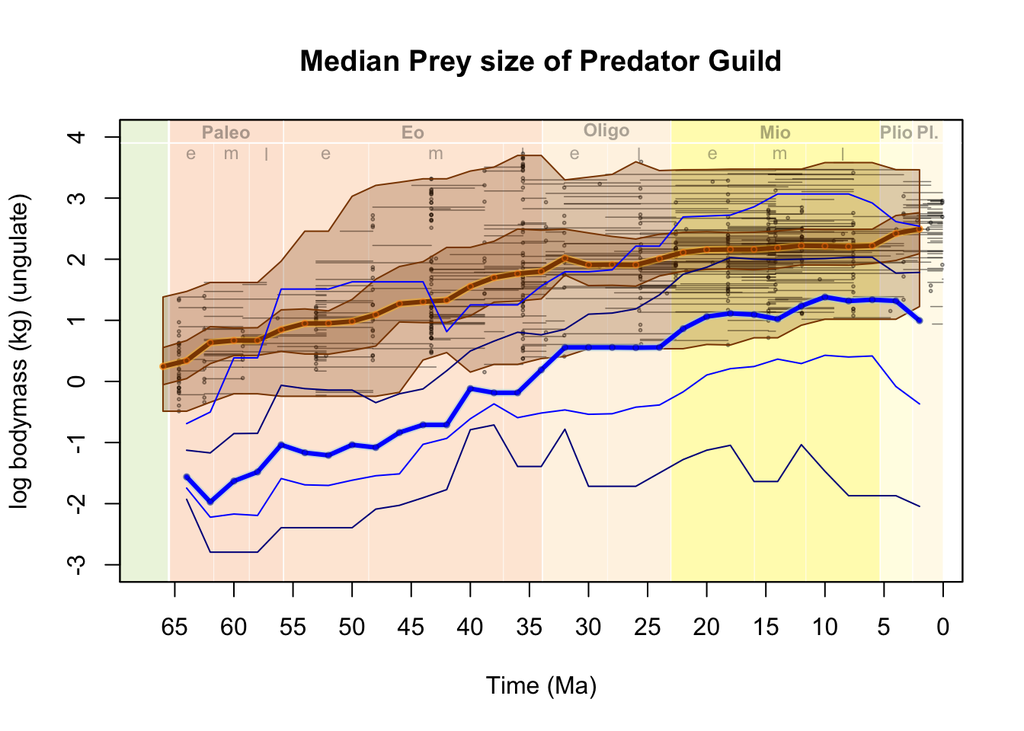

##Median Prey of Predator over 21 kg

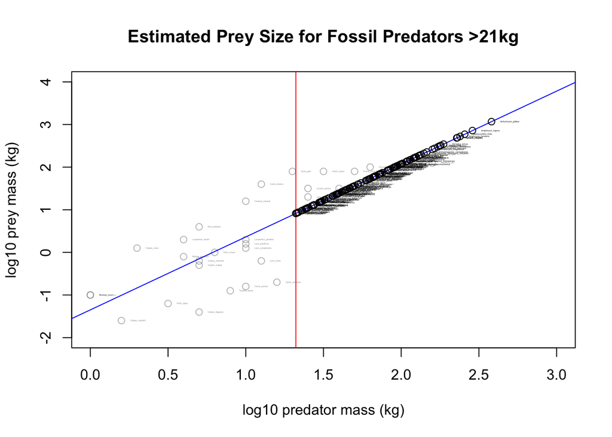

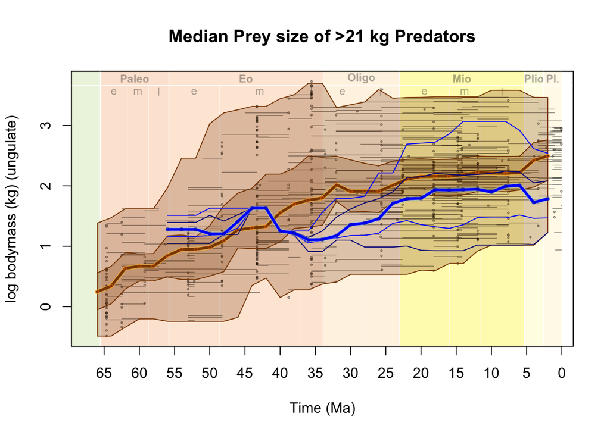

##look into habitat breakdown of those predators ##smaller in closed habitats? ###also size range prey

##hunt down max prey size ###be dynamic thing: small ungulates early on so small canrivore possible ###ungulates in range this critter could eat

#Radloff and du Toit 2004

###Some issues with these regressions is that some of the smallest carnivoes (<= 1.796 kg) regress negative values. Only run this with >21kg.

```
## [1] 74
```

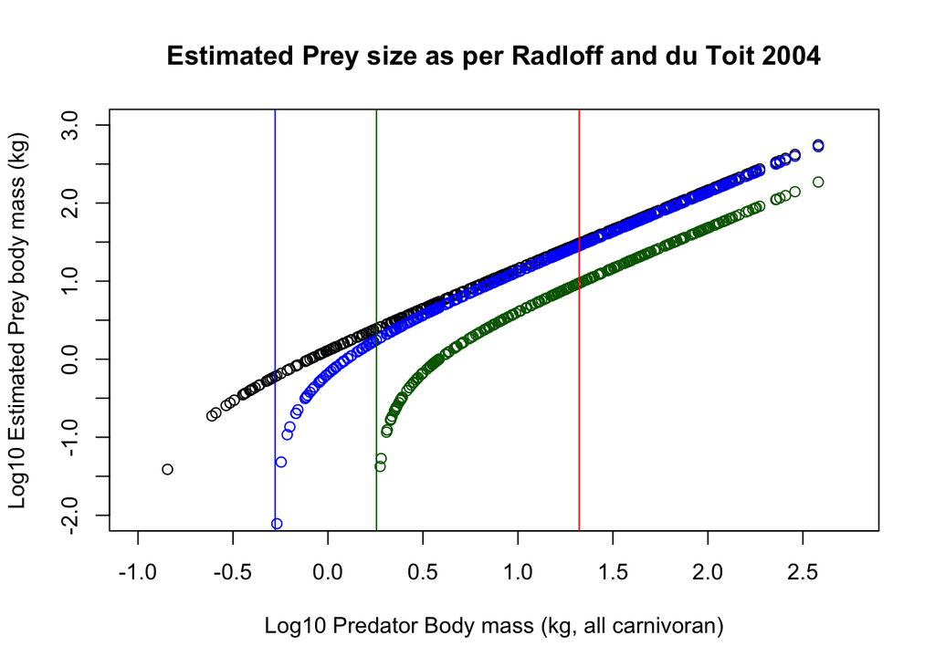

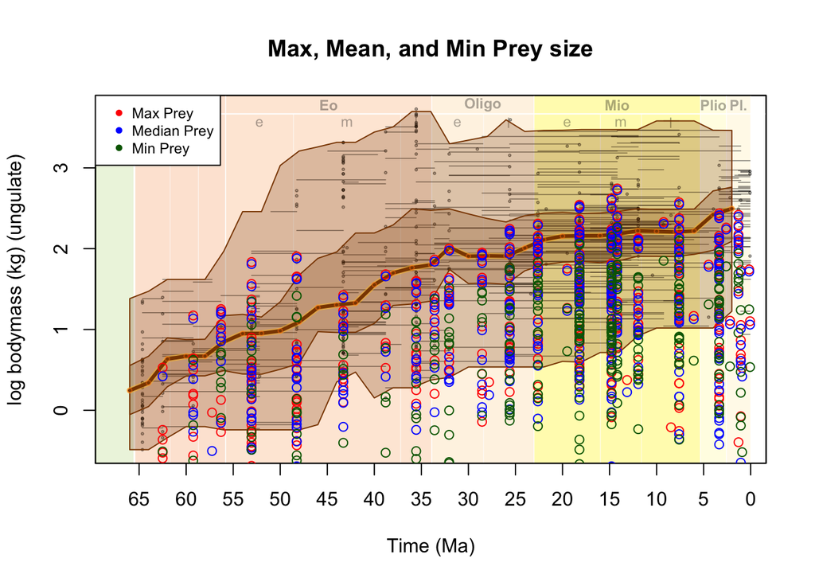

##red circles are max prey size ##blue circles are mean prey size ##green circles are min prey size

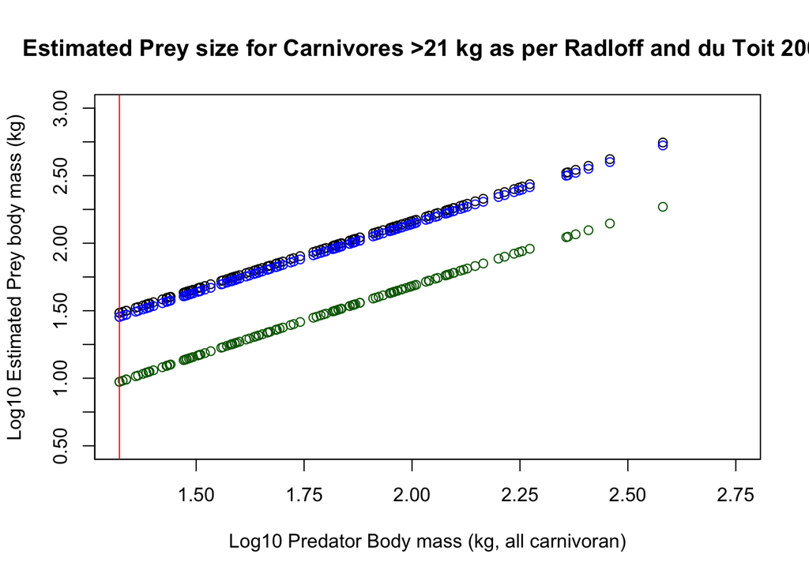

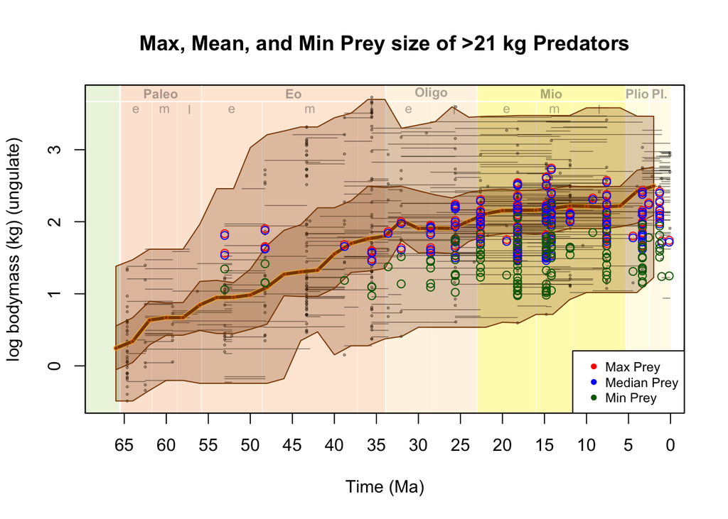

##red circles are max prey size ##blue circles are mean prey size ##green circles are min prey size

#Van Valkenburgh etal 2016 The impact of large terrestrial carnivores on Pleistocene ecosystems

```r
#unlog body mass values
#de log10 carnivore body masses
yy <- 10^pred.21up$BM_all_carnivoran

#Solitary Hunters
pred.21up$solitary.acc.prey.upp <- log10(2.2425*yy-19.49)
pred.21up$solitary.acc.prey.low <- log10(15.74*log(yy) - 33.379)
pred.21up$solitary.max.prey     <- log10(504.74*log(yy) - 1166.6)

#Group Hunters
pred.21up$group.acc.prey.upp <- log10(204.78*log(yy) - 279.59)
pred.21up$group.acc.prey.low <- log10(0.6869*yy + 2.4044)
pred.21up$group.max.prey     <- log10(22.781*yy - 92.089)
```

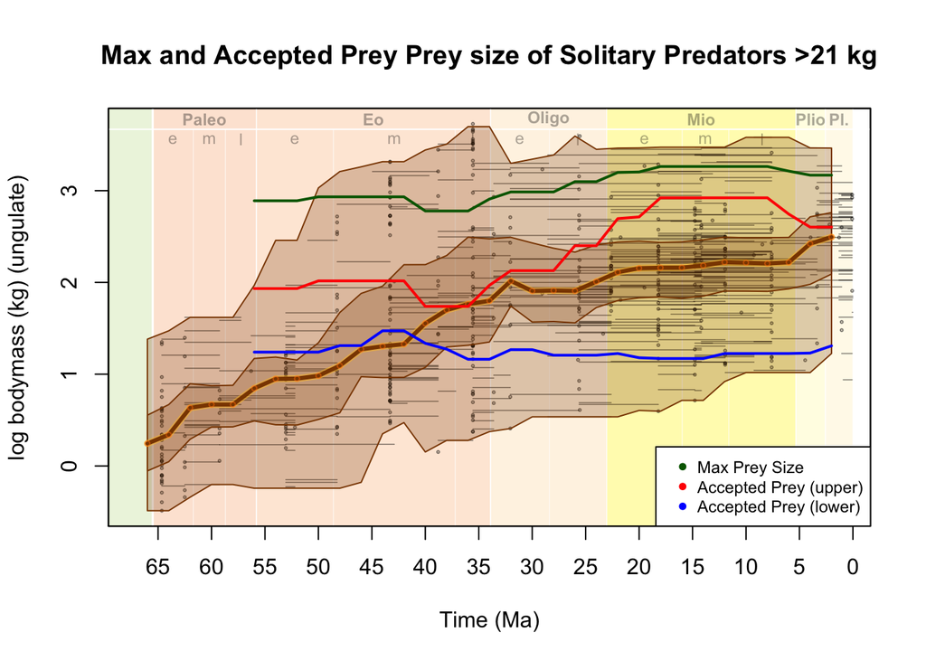

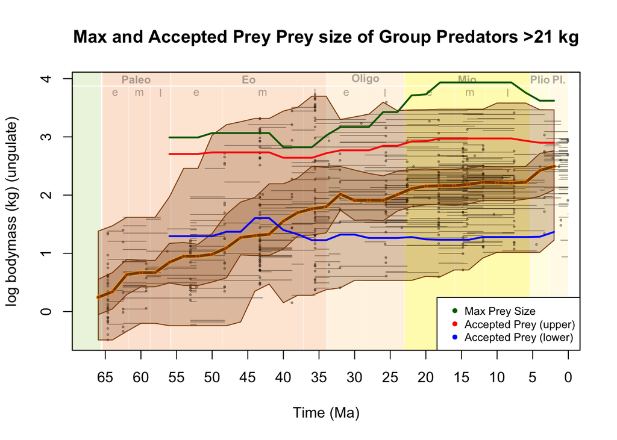